[figure not shown]

*Copyright Pierian Data*

*For more information, visit us at www.pieriandata.com*

# Seasonal Autoregressive Integrated Moving Averages

We have finally reached one of the most fascinating aspects of time series analysis: seasonality.

Where ARIMA accepts the parameters $(p,d,q)$, SARIMA accepts an *additional* set of parameters $(P,D,Q)m$ that specifically describe the seasonal components of the model. Here $P$, $D$ and $Q$ represent the seasonal regression, differencing and moving average coefficients, and $m$ represents the number of data points (rows) in each seasonal cycle.

**NOTE:** The statsmodels implementation of SARIMA is called SARIMAX. The “X” added to the name means that the function also supports *exogenous* regressor variables. We'll cover these in the next section.

### Related Functions:

```
sarimax.SARIMAX(endog[, exog, order, …])

sarimax.SARIMAXResults(model, params, …[, …])  Class to hold results from fitting a SARIMAX model.
```

### For Further Reading:

**[Statsmodels Tutorial:](https://www.statsmodels.org/stable/statespace.html)** Time Series Analysis by State Space Methods

## Perform standard imports and load datasets

```python
import pandas as pd
import numpy as np
%matplotlib inline

# Load specific forecasting tools
from statsmodels.tsa.statespace.sarimax import SARIMAX

from statsmodels.graphics.tsaplots import plot_acf,plot_pacf # for determining (p,q) orders
from statsmodels.tsa.seasonal import seasonal_decompose      # for ETS Plots
from pmdarima import auto_arima                              # for determining ARIMA orders

# Ignore harmless warnings
import warnings
warnings.filterwarnings("ignore")

# Load dataset
df = pd.read_csv('../Data/co2_mm_mlo.csv')
```

### Inspect the data, create a DatetimeIndex

```python
df.head()
```

|  | year | month | decimal_date | average | interpolated |
| --- | --- | --- | --- | --- | --- |
| 0 | 1958 | 3 | 1958.208 | 315.71 | 315.71 |
| 1 | 1958 | 4 | 1958.292 | 317.45 | 317.45 |
| 2 | 1958 | 5 | 1958.375 | 317.50 | 317.50 |
| 3 | 1958 | 6 | 1958.458 | NaN | 317.10 |
| 4 | 1958 | 7 | 1958.542 | 315.86 | 315.86 |

We need to combine two integer columns (year and month) into a DatetimeIndex. We can do this by passing a dictionary into `pandas.to_datetime()` with year, month and day values.  
For more information visit https://pandas.pydata.org/pandas-docs/stable/reference/api/pandas.to_datetime.html

```python
# Add a "date" datetime column
df['date']=pd.to_datetime(dict(year=df['year'], month=df['month'], day=1))

#another way to merge dates is  pd.to_datetime({'year':df['year'],'month':df['month'],'day':1})

# Set "date" to be the index
df.set_index('date',inplace=True)
df.index.freq = 'MS'
df.head()
```

[output not shown]

### Plot the source data

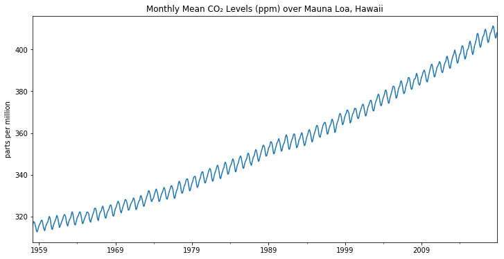

```python
title = 'Monthly Mean CO₂ Levels (ppm) over Mauna Loa, Hawaii'
ylabel='parts per million'
xlabel='' # we don't really need a label here

ax = df['interpolated'].plot(figsize=(12,6),title=title)
ax.autoscale(axis='x',tight=True)
ax.set(xlabel=xlabel, ylabel=ylabel);
```

### Run an ETS Decomposition

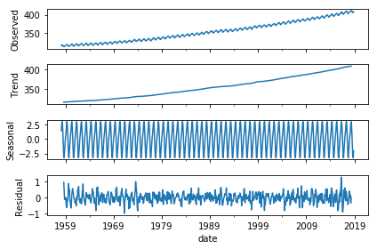

```python
result = seasonal_decompose(df['interpolated'], model='add')
result.plot();
```

Although small in scale compared to the overall values, there is a definite annual seasonality.

### Run `pmdarima.auto_arima` to obtain recommended orders

This may take awhile as there are a lot more combinations to evaluate.

```python
# For SARIMA Orders we set seasonal=True and pass in an m value
auto_arima(df['interpolated'],seasonal=True,m=12).summary()
```

Statespace Model Results

| Dep. Variable: | y | No. Observations: | 729 |
| --- | --- | --- | --- |
| Model: | SARIMAX(0, 1, 3)x(1, 0, 1, 12) | Log Likelihood | -203.092 |
| Date: | Mon, 25 Mar 2019 | AIC | 420.183 |
| Time: | 09:29:39 | BIC | 452.315 |
| Sample: | 0 | HQIC | 432.582 |
|  | - 729 |  |  |
| Covariance Type: | opg |  |  |

|  | coef | std err | z | P>\|z\| | [0.025 | 0.975] |
| --- | --- | --- | --- | --- | --- | --- |
| intercept | 0.0009 | 0.001 | 1.449 | 0.147 | -0.000 | 0.002 |
| ma.L1 | -0.3577 | 0.037 | -9.728 | 0.000 | -0.430 | -0.286 |
| ma.L2 | -0.0310 | 0.038 | -0.813 | 0.416 | -0.106 | 0.044 |
| ma.L3 | -0.0865 | 0.037 | -2.349 | 0.019 | -0.159 | -0.014 |
| ar.S.L12 | 0.9994 | 0.000 | 2999.488 | 0.000 | 0.999 | 1.000 |
| ma.S.L12 | -0.8695 | 0.021 | -42.160 | 0.000 | -0.910 | -0.829 |
| sigma2 | 0.0958 | 0.005 | 20.352 | 0.000 | 0.087 | 0.105 |

| Ljung-Box (Q): | 45.20 | Jarque-Bera (JB): | 4.09 |
| --- | --- | --- | --- |
| Prob(Q): | 0.26 | Prob(JB): | 0.13 |
| Heteroskedasticity (H): | 1.11 | Skew: | 0.01 |
| Prob(H) (two-sided): | 0.40 | Kurtosis: | 3.37 |

Warnings:  
[1] Covariance matrix calculated using the outer product of gradients (complex-step).

Excellent! This provides an ARIMA Order of (0,1,3) combined with a seasonal order of (1,0,1,12) Now let's train & test the SARIMA(0,1,3)(1,0,1,12) model, evaluate it, then produce a forecast of future values.

### Split the data into train/test sets

```python
len(df)
```

```
729
```

```python
# Set one year for testing
train = df.iloc[:717]
test = df.iloc[717:]
```

### Fit a SARIMA(0,1,3)(1,0,1,12) Model

```python
model = SARIMAX(train['interpolated'],order=(0,1,3),seasonal_order=(1,0,1,12))
results = model.fit()
results.summary()
```

Statespace Model Results

| Dep. Variable: | interpolated | No. Observations: | 717 |
| --- | --- | --- | --- |
| Model: | SARIMAX(0, 1, 3)x(1, 0, 1, 12) | Log Likelihood | -201.201 |
| Date: | Mon, 25 Mar 2019 | AIC | 414.402 |
| Time: | 09:38:36 | BIC | 441.845 |
| Sample: | 03-01-1958 | HQIC | 424.999 |
|  | - 11-01-2017 |  |  |
| Covariance Type: | opg |  |  |

|  | coef | std err | z | P>\|z\| | [0.025 | 0.975] |
| --- | --- | --- | --- | --- | --- | --- |
| ma.L1 | -0.3543 | 0.035 | -10.200 | 0.000 | -0.422 | -0.286 |
| ma.L2 | -0.0244 | 0.038 | -0.648 | 0.517 | -0.098 | 0.050 |
| ma.L3 | -0.0866 | 0.032 | -2.686 | 0.007 | -0.150 | -0.023 |
| ar.S.L12 | 0.9997 | 0.000 | 3239.477 | 0.000 | 0.999 | 1.000 |
| ma.S.L12 | -0.8680 | 0.022 | -38.921 | 0.000 | -0.912 | -0.824 |
| sigma2 | 0.0949 | 0.005 | 20.315 | 0.000 | 0.086 | 0.104 |

| Ljung-Box (Q): | 43.96 | Jarque-Bera (JB): | 4.45 |
| --- | --- | --- | --- |
| Prob(Q): | 0.31 | Prob(JB): | 0.11 |
| Heteroskedasticity (H): | 1.15 | Skew: | 0.02 |
| Prob(H) (two-sided): | 0.27 | Kurtosis: | 3.38 |

Warnings:  
[1] Covariance matrix calculated using the outer product of gradients (complex-step).

```python
# Obtain predicted values
start=len(train)
end=len(train)+len(test)-1
predictions = results.predict(start=start, end=end, dynamic=False, typ='levels').rename('SARIMA(0,1,3)(1,0,1,12) Predictions')
```

Passing `dynamic=False` means that forecasts at each point are generated using the full history up to that point (all lagged values).

Passing `typ='levels'` predicts the levels of the original endogenous variables. If we'd used the default `typ='linear'` we would have seen linear predictions in terms of the differenced endogenous variables.

For more information on these arguments visit https://www.statsmodels.org/stable/generated/statsmodels.tsa.arima_model.ARIMAResults.predict.html

```python
# Compare predictions to expected values
for i in range(len(predictions)):
    print(f"predicted={predictions[i]:<11.10}, expected={test['interpolated'][i]}")
```

```
predicted=406.6094505, expected=406.81
predicted=407.8239343, expected=407.96
predicted=408.578265 , expected=408.32
predicted=409.4831633, expected=409.41
predicted=411.036772 , expected=410.24
predicted=411.6394325, expected=411.24
predicted=410.8612658, expected=410.79
predicted=409.1726191, expected=408.71
predicted=407.0722543, expected=406.99
predicted=405.6214644, expected=405.51
predicted=405.8902221, expected=406.0
predicted=407.4224706, expected=408.02
```

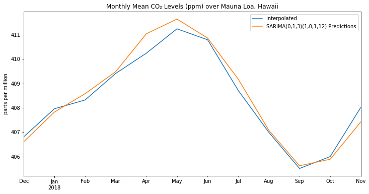

```python
# Plot predictions against known values
title = 'Monthly Mean CO₂ Levels (ppm) over Mauna Loa, Hawaii'
ylabel='parts per million'
xlabel=''

ax = test['interpolated'].plot(legend=True,figsize=(12,6),title=title)
predictions.plot(legend=True)
ax.autoscale(axis='x',tight=True)
ax.set(xlabel=xlabel, ylabel=ylabel);
```

### Evaluate the Model

```python
from sklearn.metrics import mean_squared_error

error = mean_squared_error(test['interpolated'], predictions)
print(f'SARIMA(0,1,3)(1,0,1,12) MSE Error: {error:11.10}')

from statsmodels.tools.eval_measures import rmse

error = rmse(test['interpolated'], predictions)
print(f'SARIMA(0,1,3)(1,0,1,12) RMSE Error: {error:11.10}')
```

[output not shown]

These are outstanding results!

### Retrain the model on the full data, and forecast the future

```python
model = SARIMAX(df['interpolated'],order=(0,1,3),seasonal_order=(1,0,1,12))
results = model.fit()
fcast = results.predict(len(df),len(df)+11,typ='levels').rename('SARIMA(0,1,3)(1,0,1,12) Forecast')

# Plot predictions against known values
title = 'Monthly Mean CO₂ Levels (ppm) over Mauna Loa, Hawaii'
ylabel='parts per million'
xlabel=''

ax = df['interpolated'].plot(legend=True,figsize=(12,6),title=title)
fcast.plot(legend=True)
ax.autoscale(axis='x',tight=True)
ax.set(xlabel=xlabel, ylabel=ylabel);
```

[output not shown]